# Practical Machine Learning - Course Project

Trieu Tran

November 14, 2015

### Summary

This is the course project for the Practical Machine Learning class. The goal of this project is to build a prediction model for “how well” people do a simple “Unilateral Dumbbell Biceps Curl” exercise. The data for buidling the model was collected from sensors attached to the belt, forearm, arm, and dumbell of 6 participants. They were asked to perform dumbell lifts correctly and incorrectly in 5 different ways. The quality of these participants’ exercises were recorded and were categorized as Class A, Class B, Class C, Class D and Class E. Class A corresponds to correct execution of the “Biceps Curl” exercise, the other 4 classes correspond to incorrect executions with common mistakes.

The report describes how we perform data clean-up; how we apply different machine learning algorithms such as RPart, GBM and Random Forest on the training dataset; and how we determine the best prediction model and expected out-of-sample error. To validate our prediction model, we run our model against the test data of 20 cases, and successfully get 20 correct predictions.

**Data Source**

The training data for this project are available here: https://d396qusza40orc.cloudfront.net/predmachlearn/pml-training.csv

The test data are available here: https://d396qusza40orc.cloudfront.net/predmachlearn/pml-testing.csv

We would like to thank a group of researchers who let us use their dataset for this project. *Velloso, E.; Bulling, A.; Gellersen, H.; Ugulino, W.; Fuks, H. [Qualitative Activity Recognition of Weight Lifting Exercises.](http://groupware.les.inf.puc-rio.br/work.jsf?p1=11201) Proceedings of 4th International Conference in Cooperation with SIGCHI (Augmented Human ’13) . Stuttgart, Germany: ACM SIGCHI, 2013.*

More information is available here: http://groupware.les.inf.puc-rio.br/har (see the section on the Weight Lifting Exercise Dataset).

### Data Exploration

First, we download csv files from the above mentioned links, and then use R’s function to parse these csv files to R datasets. For data fields which contain NA, #DIV/0 or blank spaces, we treat them as NA.

```r
##http://icetornado.github.io/practical_machine_learning_project/
## loading libraries
library(caret)
library(randomForest)
library(doParallel)

registerDoParallel()

if (!file.exists("data")){
    dir.create("data")
}

# figureDir <- 'figure'
# if (!file.exists(figureDir)){
#     dir.create(figureDir)
# }

## downloading csv files
if (!file.exists(file.path("data", "pml-training.csv"))) {
        message("Downloading training file")
        download.file("https://d396qusza40orc.cloudfront.net/predmachlearn/pml-training.csv", destfile = file.path("data", "pml-training.csv"))
}

if (!file.exists(file.path("data", "pml-testing.csv"))) {
        message("Downloading testing file")
        download.file("https://d396qusza40orc.cloudfront.net/predmachlearn/pml-testing.csv", destfile = file.path("data", "pml-testing.csv"))
}

##loading training and testing data from csv files
message("reading raw csv files")
rawTraining <- read.csv(file.path("data", "pml-training.csv"), stringsAsFactors=FALSE, na.strings = c("NA","#DIV/0!",""))
rawTesting <- read.csv(file.path("data", "pml-testing.csv"), stringsAsFactors=FALSE, na.strings = c("NA","#DIV/0!",""))
```

We use the **caret** package for the major part of creating predictive models for this project. We first use the package’s **createDataPartition** function to split data (with a split ratio 60/40) read from the training csv file into two datasets, which are named as **training** and **testing**.

```r
set.seed(124567)
inTrain <- createDataPartition(y=rawTraining$classe, p=0.6, list=FALSE)
training <- rawTraining[inTrain, ]
testing <- rawTraining[-inTrain, ]

str(training, list.len=30)
```

```
## 'data.frame':    11776 obs. of  160 variables:
##  $ X                       : int  1 2 3 4 5 6 7 12 14 16 ...
##  $ user_name               : chr  "carlitos" "carlitos" "carlitos" "carlitos" ...
##  $ raw_timestamp_part_1    : int  1323084231 1323084231 1323084231 1323084232 1323084232 1323084232 1323084232 1323084232 1323084232 1323084232 ...
##  $ raw_timestamp_part_2    : int  788290 808298 820366 120339 196328 304277 368296 528316 576390 644302 ...
##  $ cvtd_timestamp          : chr  "05/12/2011 11:23" "05/12/2011 11:23" "05/12/2011 11:23" "05/12/2011 11:23" ...
##  $ new_window              : chr  "no" "no" "no" "no" ...
##  $ num_window              : int  11 11 11 12 12 12 12 12 12 12 ...
##  $ roll_belt               : num  1.41 1.41 1.42 1.48 1.48 1.45 1.42 1.43 1.42 1.48 ...
##  $ pitch_belt              : num  8.07 8.07 8.07 8.05 8.07 8.06 8.09 8.18 8.21 8.15 ...
##  $ yaw_belt                : num  -94.4 -94.4 -94.4 -94.4 -94.4 -94.4 -94.4 -94.4 -94.4 -94.4 ...
##  $ total_accel_belt        : int  3 3 3 3 3 3 3 3 3 3 ...
##  $ kurtosis_roll_belt      : num  NA NA NA NA NA NA NA NA NA NA ...
##  $ kurtosis_picth_belt     : num  NA NA NA NA NA NA NA NA NA NA ...
##  $ kurtosis_yaw_belt       : logi  NA NA NA NA NA NA ...
```

[output cut: 17 more lines]

```r
table(training$classe)
```

```
##
##    A    B    C    D    E
## 3348 2279 2054 1930 2165
```

### Data Cleaning

We inspect our **training** data set and discover that there is quite a number of variables that have mostly NAs. These variables don’t contribute anything toward buidling our models. Therefore, we go through the list of variables, and remove ones in which NAs made up more than 80% of its data. In addition, we also remove the first 7 variables because they are not actual movement data from the sensors.

A very handy function of the **caret** package, **findCorrelation**, helps us to identify highly corelated variables. We use the function with a cutoff setting at 0.5; and get a list a variables which we can remove from the data. However, for testing whether “the more variables is the more accuracy model”, we keep the original 53-variable training and test dataset (named **training** and **testing**). We also create two new 22-variable datasets with the exclusion of the highly related variables: **training1** and **testing1**.

```r
## counting NAs in each column, and returning a list of columns which have  > 80% NAs
naList <- data.frame(ord = integer(0), name = character(0), cnNA = integer(0))
for(j in 1:length(training)) {
        if(sum(is.na(training[, j])) / length(training[,j]) > 0.8) {
                naList <- rbind(naList, data.frame(ord = j, name = names(training)[j], cnNA = sum(is.na(training[, j]))))
        }
}

## remove columns from the 1st to 7th ()
removeCols <- c(1:7, naList$ord)

training <- training[-removeCols]
testing <- testing[-removeCols]

## eliminating highly correlated variables
correlationMatrix <- cor(training[-53])
highlyCorrelated <- findCorrelation(correlationMatrix, cutoff=0.5)

training1 = training[-highlyCorrelated]
testing1 = testing[-highlyCorrelated]
```

### Models Training

#### Decision Tree with 22 variables

```r
## declaring fit control
fitControl <- trainControl(
        method = "repeatedcv",
        number = 10,
        repeats = 3)

registerDoParallel()
fitRPart <- train(classe ~ ., method = "rpart", data = training1, trControl = fitControl)
predictRPart <- predict(fitRPart, testing[, -22])
confusionRPart <- confusionMatrix(testing1[, 22], predictRPart)
print(confusionRPart)
```

```
## Confusion Matrix and Statistics
##
##           Reference
## Prediction    A    B    C    D    E
##          A 1882   94  146   68   42
##          B  553  425  332  202    6
##          C  595   66  633    2   72
##          D  346  149  290  387  114
##          E  316  165  276   59  626
##
## Overall Statistics
##
##                Accuracy : 0.5038
##                  95% CI : (0.4927, 0.5149)
##     No Information Rate : 0.4706
##     P-Value [Acc > NIR] : 1.97e-09
##
##                   Kappa : 0.3569
##  Mcnemar's Test P-Value : < 2.2e-16
##
## Statistics by Class:
##
##                      Class: A Class: B Class: C Class: D Class: E
## Sensitivity            0.5098  0.47275  0.37746  0.53900  0.72791
## Specificity            0.9157  0.84267  0.88086  0.87388  0.88319
## Pos Pred Value         0.8432  0.27997  0.46272  0.30093  0.43412
## Neg Pred Value         0.6776  0.92509  0.83884  0.94954  0.96346
## Prevalence             0.4706  0.11458  0.21374  0.09151  0.10961
## Detection Rate         0.2399  0.05417  0.08068  0.04932  0.07979
## Detection Prevalence   0.2845  0.19347  0.17436  0.16391  0.18379
## Balanced Accuracy      0.7127  0.65771  0.62916  0.70644  0.80555
```

#### Decision Tree with 53 variables

```r
registerDoParallel()
fitRPartBig <- train(classe ~ ., method = "rpart", data = training, trControl = fitControl)
predictRPartBig <- predict(fitRPartBig, testing[, -53])
confusionRPartBig <- confusionMatrix(testing[, 53], predictRPartBig)
print(confusionRPartBig)
```

```
## Confusion Matrix and Statistics
##
##           Reference
## Prediction    A    B    C    D    E
##          A 2034   32  160    0    6
##          B  618  525  375    0    0
##          C  637   46  685    0    0
##          D  578  226  482    0    0
##          E  210  193  366    0  673
##
## Overall Statistics
##
##                Accuracy : 0.4992
##                  95% CI : (0.4881, 0.5104)
##     No Information Rate : 0.5196
##     P-Value [Acc > NIR] : 0.9999
##
##                   Kappa : 0.3455
##  Mcnemar's Test P-Value : NA
##
## Statistics by Class:
##
##                      Class: A Class: B Class: C Class: D Class: E
## Sensitivity            0.4989  0.51370  0.33124       NA  0.99116
## Specificity            0.9475  0.85448  0.88179   0.8361  0.89270
## Pos Pred Value         0.9113  0.34585  0.50073       NA  0.46671
## Neg Pred Value         0.6361  0.92146  0.78651       NA  0.99906
## Prevalence             0.5196  0.13026  0.26357   0.0000  0.08654
## Detection Rate         0.2592  0.06691  0.08731   0.0000  0.08578
## Detection Prevalence   0.2845  0.19347  0.17436   0.1639  0.18379
## Balanced Accuracy      0.7232  0.68409  0.60652       NA  0.94193
```

#### GBM with 22 variables

```r
registerDoParallel()
fitGBM <- train(classe ~ ., method = "gbm", data = training1, verbose = FALSE, trControl = fitControl)
predictGBM <- predict(fitGBM, testing1[, -22])
confusionGBM <- confusionMatrix(testing1[, 22], predictGBM)
print(confusionGBM)
```

```
## Confusion Matrix and Statistics
##
##           Reference
## Prediction    A    B    C    D    E
##          A 2055   51   49   72    5
##          B  127 1231   98   34   28
##          C   17  105 1194   24   28
##          D   10   35  118 1105   18
##          E   13   56   44   34 1295
##
## Overall Statistics
##
##                Accuracy : 0.8769
##                  95% CI : (0.8694, 0.8841)
##     No Information Rate : 0.2832
##     P-Value [Acc > NIR] : < 2.2e-16
##
##                   Kappa : 0.8443
##  Mcnemar's Test P-Value : < 2.2e-16
##
## Statistics by Class:
##
##                      Class: A Class: B Class: C Class: D Class: E
## Sensitivity            0.9248   0.8329   0.7944   0.8708   0.9425
## Specificity            0.9685   0.9549   0.9726   0.9725   0.9773
## Pos Pred Value         0.9207   0.8109   0.8728   0.8593   0.8981
## Neg Pred Value         0.9703   0.9610   0.9523   0.9750   0.9877
## Prevalence             0.2832   0.1884   0.1916   0.1617   0.1751
## Detection Rate         0.2619   0.1569   0.1522   0.1408   0.1651
## Detection Prevalence   0.2845   0.1935   0.1744   0.1639   0.1838
## Balanced Accuracy      0.9467   0.8939   0.8835   0.9216   0.9599
```

#### GBM with 53 variables

```r
registerDoParallel()
fitGBMBig <- train(classe ~ ., method = "gbm", data = training, verbose = FALSE, trControl = fitControl)
predictGBMBig <- predict(fitGBMBig, testing[, -53])
confusionGBMBig <- confusionMatrix(testing[, 53], predictGBMBig)
print(confusionGBMBig)
```

```
## Confusion Matrix and Statistics
##
##           Reference
## Prediction    A    B    C    D    E
##          A 2190   23   16    2    1
##          B   56 1422   36    2    2
##          C    0   58 1288   20    2
##          D    1    5   34 1237    9
##          E    3   15    7   12 1405
##
## Overall Statistics
##
##                Accuracy : 0.9613
##                  95% CI : (0.9567, 0.9654)
##     No Information Rate : 0.2868
##     P-Value [Acc > NIR] : < 2.2e-16
##
##                   Kappa : 0.951
##  Mcnemar's Test P-Value : 4.212e-08
##
## Statistics by Class:
##
##                      Class: A Class: B Class: C Class: D Class: E
## Sensitivity            0.9733   0.9337   0.9327   0.9717   0.9901
## Specificity            0.9925   0.9848   0.9876   0.9925   0.9942
## Pos Pred Value         0.9812   0.9368   0.9415   0.9619   0.9743
## Neg Pred Value         0.9893   0.9840   0.9856   0.9945   0.9978
## Prevalence             0.2868   0.1941   0.1760   0.1622   0.1809
## Detection Rate         0.2791   0.1812   0.1642   0.1577   0.1791
## Detection Prevalence   0.2845   0.1935   0.1744   0.1639   0.1838
## Balanced Accuracy      0.9829   0.9593   0.9601   0.9821   0.9922
```

#### Random Forest with 22 variables

```r
registerDoParallel()
fitRF <- train(classe~ ., data=training1, method="rf", trControl=fitControl, verbose = FALSE)
predictRF <- predict(fitRF, newdata = testing1)
confusionRF <- confusionMatrix(predictRF, testing1$classe)
print(confusionRF)
```

```
## Confusion Matrix and Statistics
##
##           Reference
## Prediction    A    B    C    D    E
##          A 2218   22    2    2    1
##          B    9 1477   24    2    0
##          C    2   10 1331   40    0
##          D    0    3   11 1240    7
##          E    3    6    0    2 1434
##
## Overall Statistics
##
##                Accuracy : 0.9814
##                  95% CI : (0.9782, 0.9843)
##     No Information Rate : 0.2845
##     P-Value [Acc > NIR] : < 2.2e-16
##
##                   Kappa : 0.9765
##  Mcnemar's Test P-Value : NA
##
## Statistics by Class:
##
##                      Class: A Class: B Class: C Class: D Class: E
## Sensitivity            0.9937   0.9730   0.9730   0.9642   0.9945
## Specificity            0.9952   0.9945   0.9920   0.9968   0.9983
## Pos Pred Value         0.9880   0.9769   0.9624   0.9833   0.9924
## Neg Pred Value         0.9975   0.9935   0.9943   0.9930   0.9988
## Prevalence             0.2845   0.1935   0.1744   0.1639   0.1838
## Detection Rate         0.2827   0.1882   0.1696   0.1580   0.1828
## Detection Prevalence   0.2861   0.1927   0.1763   0.1607   0.1842
## Balanced Accuracy      0.9945   0.9837   0.9825   0.9805   0.9964
```

#### Random Forest with 53 variables

```r
registerDoParallel()
fitMoreRF <- train(classe~ ., data=training, method="rf", trControl=fitControl, verbose = FALSE)
predictMoreRF <- predict(fitMoreRF, newdata = testing)
confusionMoreRF <- confusionMatrix(predictMoreRF, testing$classe)
print(confusionMoreRF)
```

```
## Confusion Matrix and Statistics
##
##           Reference
## Prediction    A    B    C    D    E
##          A 2229    2    0    0    0
##          B    3 1509   16    0    0
##          C    0    7 1350   27    0
##          D    0    0    2 1258    3
##          E    0    0    0    1 1439
##
## Overall Statistics
##
##                Accuracy : 0.9922
##                  95% CI : (0.99, 0.994)
##     No Information Rate : 0.2845
##     P-Value [Acc > NIR] : < 2.2e-16
##
##                   Kappa : 0.9902
##  Mcnemar's Test P-Value : NA
##
## Statistics by Class:
##
##                      Class: A Class: B Class: C Class: D Class: E
## Sensitivity            0.9987   0.9941   0.9868   0.9782   0.9979
## Specificity            0.9996   0.9970   0.9948   0.9992   0.9998
## Pos Pred Value         0.9991   0.9876   0.9754   0.9960   0.9993
## Neg Pred Value         0.9995   0.9986   0.9972   0.9957   0.9995
## Prevalence             0.2845   0.1935   0.1744   0.1639   0.1838
## Detection Rate         0.2841   0.1923   0.1721   0.1603   0.1834
## Detection Prevalence   0.2843   0.1947   0.1764   0.1610   0.1835
## Balanced Accuracy      0.9991   0.9955   0.9908   0.9887   0.9989
```

#### Comparing models

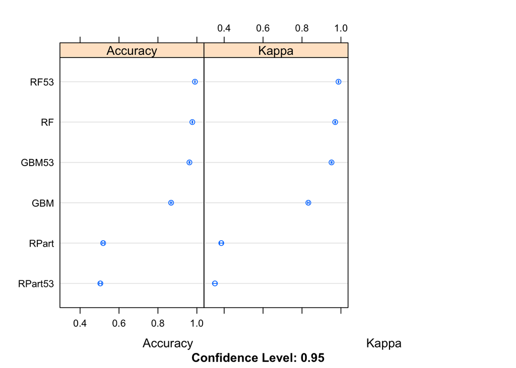

```r
# comparing models
modelList <- list(
        RPart = fitRPart,
        RPart53 = fitRPartBig,
        GBM = fitGBM,
        GBM53 = fitGBMBig,
        RF = fitRF,
        RF53 = fitMoreRF)

resamps <- resamples(modelList)
dotplot(resamps, layout = c(3, 1))
```

The Random Forest algorithm yields the best results with an accuracy rates of **98.14%** on the model built of 22 variables (named **RF**) and an accuracy rate of **99.22%** on the model built of 53 variables (named **RF53**). We decide to choose the model **RF** with 22 variables because of its simplicity and its acceptable accuracy.

**Estimate of out-of-sample error** is 100% - 98.14% = **1.86%**

### Project submission

We conduct testing on all models againts a dataset of 20 observations and print out the test results as follows:

```r
pml_write_files = function(x){
        n = length(x)
        for(i in 1:n){
                filename = paste0("problem_id_",i,".txt")
                write.table(x[i],file=file.path("results",filename),quote=FALSE,row.names=FALSE,col.names=FALSE)
        }
}

for(j in 1:length(modelList)) {
        tP <- predict(modelList[j],  newdata = rawTesting)
        print(tP)
        if(j == 5) {      ## the second best model
                pml_write_files(tP)
        }
}
```

```
## $RPart
##  [1] C A C A A C C A A A B C C A C A A D A C
## Levels: A B C D E
##
## $RPart53
##  [1] C A C A A C C A A A C C C A C A A A A C
## Levels: A B C D E
##
## $GBM
##  [1] B A B A A E D B A C C C B A E E A B A B
## Levels: A B C D E
##
## $GBM53
##  [1] B A B A A E D B A A B C B A E E A B B B
## Levels: A B C D E
##
## $RF
##  [1] B A B A A E D B A A B C B A E E A B B B
## Levels: A B C D E
##
## $RF53
##  [1] B A B A A E D B A A B C B A E E A B B B
## Levels: A B C D E
```

From the above test outcomes, we can see that the model **RF** and the model **RF53** give identical results. As mentioned earlier we choose our second best model to generate text files to submit to the Coursera’s server. The feedback score from the server is a perfect 20/20.